# ASSIGNMENT 1 : STAT20230

Author

Shubh Gaur(23200555)

# QUESTION 3

## Importing Libraries

```r
library(tidyverse)
library(knitr)
library(ggplot2)
library(corrplot)
library(data.table)
```

## Load the bodyfat dataset

```r
library(mfp)
data("bodyfat")
head(bodyfat)
```

```
  case brozek siri density age weight height neck chest abdomen   hip thigh
1    1   12.6 12.3  1.0708  23 154.25  67.75 36.2  93.1    85.2  94.5  59.0
2    2    6.9  6.1  1.0853  22 173.25  72.25 38.5  93.6    83.0  98.7  58.7
3    3   24.6 25.3  1.0414  22 154.00  66.25 34.0  95.8    87.9  99.2  59.6
4    4   10.9 10.4  1.0751  26 184.75  72.25 37.4 101.8    86.4 101.2  60.1
5    5   27.8 28.7  1.0340  24 184.25  71.25 34.4  97.3   100.0 101.9  63.2
6    6   20.6 20.9  1.0502  24 210.25  74.75 39.0 104.5    94.4 107.8  66.0
  knee ankle biceps forearm wrist
1 37.3  21.9   32.0    27.4  17.1
2 37.3  23.4   30.5    28.9  18.2
3 38.9  24.0   28.8    25.2  16.6
4 37.3  22.8   32.4    29.4  18.2
5 42.2  24.0   32.2    27.7  17.7
6 42.0  25.6   35.7    30.6  18.8
```

## Fitting a linear regression to Y : body fat (%) versus X: weight (in kg)

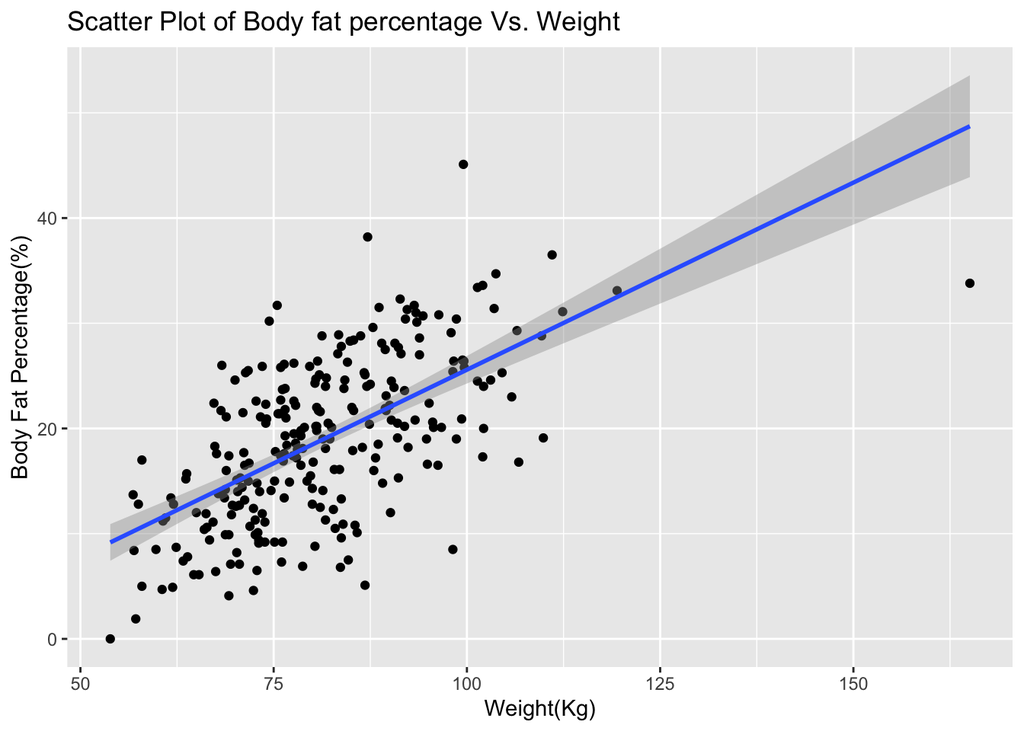

```r
y=bodyfat$brozek
x=bodyfat$weight/2.2
ggplot(data=NULL,aes(x = x, y = y))+ geom_point() +
  geom_smooth(method = 'lm')+
  labs(x = "Weight(Kg)",
    y = "Body Fat Percentage(%)",
    title = "Scatter Plot of Body fat percentage Vs. Weight"
  )
```

```r
n=length(x)
beta1 = (sum(x*y) - n*mean(x)*mean(y))/(sum(x^2) - n*mean(x)^2)
beta0 = mean(y)-beta1*mean(x)
print(paste('Slope of linear regression=',beta1))
```

```
[1] "Slope of linear regression= 0.355759264744598"
```

```r
print(paste('Y Intercept=',beta0))
```

```
[1] "Y Intercept= -9.99515097421709"
```

### Comparing coefficients using lm

```r
model1=lm(y~x)
model1
```

```
Call:
lm(formula = y ~ x)

Coefficients:
(Intercept)            x
    -9.9952       0.3558
```

We can see that we have correctly fitted the model by comparing the coefficients.

#### A

beta_0 is the y intercept which is the value when X=0 which in this case is a negative value which doesn’t make sense because body fat percentage can never be negative and also body fat percentage for a weightless(X=Weight=0) body doesn’t make sense.Also, beta_0 is obtained by setting all the variables to zero,which in real world applications doesn’t have a meaningful interpretation.Eg. in a model predicting house prices, what does it mean for all the variables (bedrooms,baths,etc.) to be 0, such an interpretation lacks practical significance.

Because of the above reasons, beta_0 interpretation should be avoided.

#### B

```r
x1=x # weight in kg
x2=bodyfat$abdomen

model2=lm(y~x1+x2)

cat(paste0("Regression Coeffecient of weight(X1) for the model with single covariate:\n",
            "X1: Weight(in Kgs)\n",
            "= ",beta1,"\n"))
```

```
Regression Coeffecient of weight(X1) for the model with single covariate:
X1: Weight(in Kgs)
= 0.355759264744598
```

```r
cat(paste0("Regression Coeffecient of weight(X1) for the model with dual covariates:\n",
            "X1: Weight(in Kgs)\n",
            "X2: Abdomen circumference(cms)\n",
            "= ",coef(model2)[2],"\n"))
```

```
Regression Coeffecient of weight(X1) for the model with dual covariates:
X1: Weight(in Kgs)
X2: Abdomen circumference(cms)
= -0.300197643478274
```

```r
cat(paste0("Regression coefficient of Abdomen Circumference(X2) in the new model= "
           ,coef(model2)[3],"\n"))
```

```
Regression coefficient of Abdomen Circumference(X2) in the new model= 0.91513804534707
```

The estimated effect of weight has changed from a positive value in the first model to a negative value in the second model.

The reason for this is the new covariate : Abdomen Circumference(cms) is highly positively correlated with the dependent variable: Bodyfat Percentage and first covariate: Weight(in Kgs) and acting as a confounder.

Lets verify the above claim using a plot of correlation:

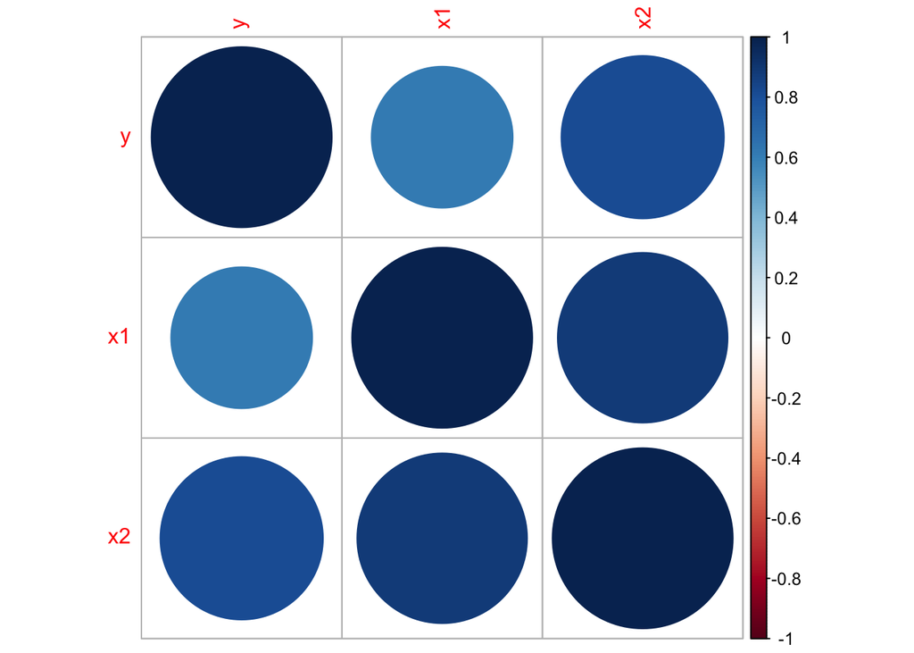

```r
corrplot(cor(data.frame(y,x1,x2)))
```

As we can see the covariate X2 is highly positively correlated with dependent variable Y & covariate X1. So, as X2 gets larger X1 will also get larger and the outcome would be on overestimation of Y(if the regression coefficient of X1 had not changed signs in the second model): the dependent variable. So, to avoid this overestimation, the regression coefficient of X1 in the second model has changed its sign from positive to negative due to its high correlation with X2.

#### C

```r
summary(model1)
```

```
Call:
lm(formula = y ~ x)

Residuals:
    Min      1Q  Median      3Q     Max
-16.434  -4.315   0.079   4.540  19.681

Coefficients:
            Estimate Std. Error t value Pr(>|t|)
(Intercept) -9.99515    2.38906  -4.184 3.97e-05 ***
x            0.35576    0.02899  12.273  < 2e-16 ***
---
Signif. codes:  0 '***' 0.001 '**' 0.01 '*' 0.05 '.' 0.1 ' ' 1

Residual standard error: 6.135 on 250 degrees of freedom
Multiple R-squared:  0.376, Adjusted R-squared:  0.3735
F-statistic: 150.6 on 1 and 250 DF,  p-value: < 2.2e-16
```

```r
summary(model2)
```

```
Call:
lm(formula = y ~ x1 + x2)

Residuals:
     Min       1Q   Median       3Q      Max
-10.8307  -2.9773   0.0237   2.9397   9.7679

Coefficients:
             Estimate Std. Error t value Pr(>|t|)
(Intercept) -41.34812    2.41299 -17.136  < 2e-16 ***
x1           -0.30020    0.04241  -7.079 1.47e-11 ***
x2            0.91514    0.05254  17.419  < 2e-16 ***
---
Signif. codes:  0 '***' 0.001 '**' 0.01 '*' 0.05 '.' 0.1 ' ' 1

Residual standard error: 4.127 on 249 degrees of freedom
Multiple R-squared:  0.7187,    Adjusted R-squared:  0.7165
F-statistic: 318.1 on 2 and 249 DF,  p-value: < 2.2e-16
```

```r
cat(paste0("Coeffiecient of determination for model 1= ",
           summary(model1)$r.squared),"\n")
```

```
Coeffiecient of determination for model 1= 0.375960415268732
```

```r
cat(paste0("Coeffiecient of determination for model 2= ",
           summary(model2)$r.squared),"\n")
```

```
Coeffiecient of determination for model 2= 0.718726452981408
```

It is evident from the coefficient of determination that the second model provides a better fit for the data and this is due to the fact that X2 was a confounding variable and as long as it was not introduced ,there was bias in the model which contributed to the relatively lower value for coefficient of determination.

# QUESTION 4

## Reading Data File

```r
data=read.csv('data_simulation.csv')
head(data)
```

```
           y X1        X2        X3
1  6.3200411  6 0.9477644 0.5604356
2  5.1830886  7 1.7181174 0.7957037
3  0.5988436  2 0.9534741 0.5858352
4  4.8122950  6 2.0977570 0.6113976
5  3.5291469  6 0.6679458 0.7317442
6 -0.1604793  3 0.5583715 0.4340481
```

## Generating 1000 samples of size 300 to get a sampling distribution for regression coefficients

```r
n = 300
values = matrix(NA, ncol =4, nrow = 1000)
for(i in 1:1000){
sampled_indexes = sample(1:10000, size = n)
data_sample = data[sampled_indexes,]
model=lm(y~X1+X2+X3,data=data_sample)
values[i,]=coef(model)
}
```

#### A

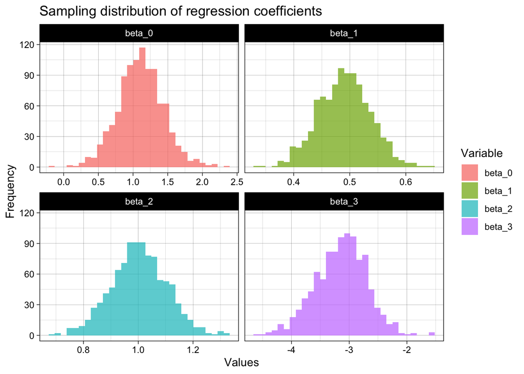

```r
df=data.frame(values)
colnames(df)=c('beta_0','beta_1','beta_2','beta_3')
# casting the dataframe into long format
df=pivot_longer(df, cols = everything(), names_to = "Variable")

#plotting histogram for sampling distribution of regression coefficients
ggplot(df, aes(x = value, fill = Variable)) +
  geom_histogram(alpha = 0.7) +
  labs(
    title = "Sampling distribution of regression coefficients",
    x = "Values",
    y = "Frequency"
  ) +
  theme_linedraw() + facet_wrap(~Variable, scales = "free_x")
```

#### B

```r
#PLOTTING CORRELATION BETWEEN ESTIMATES
df=data.frame(values)
colnames(df)=c('beta_0','beta_1','beta_2','beta_3')
correlation_mat=cor(df)
kable(correlation_mat) #correlation matrix
```

|  | beta_0 | beta_1 | beta_2 | beta_3 |
| --- | --- | --- | --- | --- |
| beta_0 | 1.0000000 | -0.6560588 | -0.1843413 | -0.6278642 |
| beta_1 | -0.6560588 | 1.0000000 | 0.0201151 | -0.0468542 |
| beta_2 | -0.1843413 | 0.0201151 | 1.0000000 | -0.0613349 |
| beta_3 | -0.6278642 | -0.0468542 | -0.0613349 | 1.0000000 |

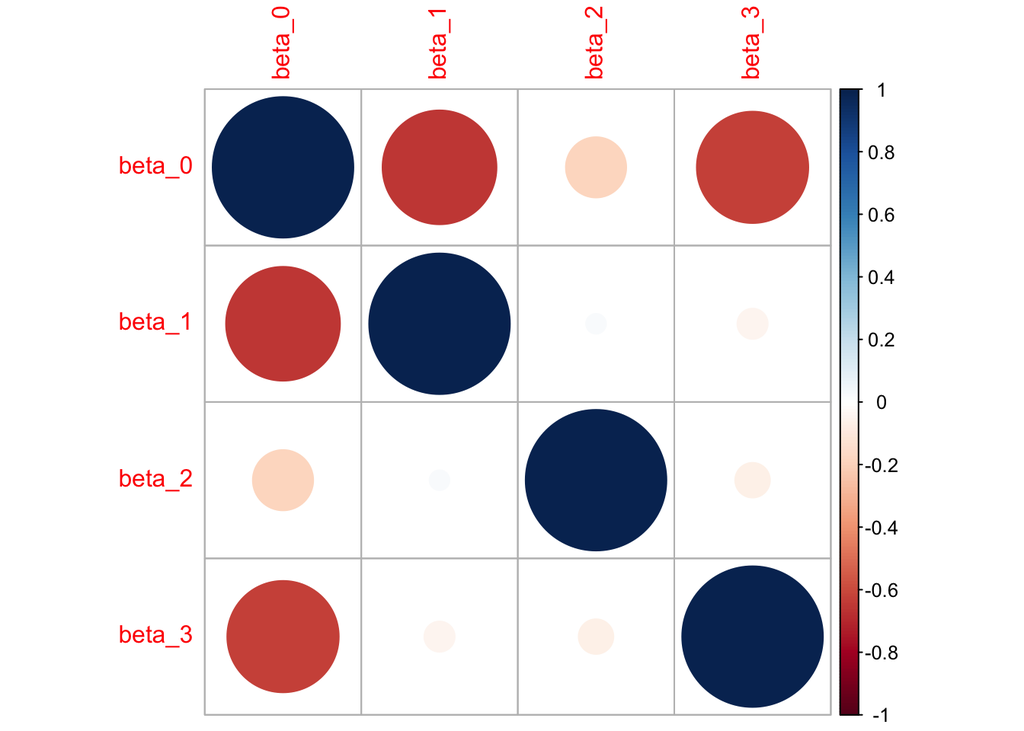

```r
#correlation plot
corrplot(correlation_mat)
```

#### C

As we are able to see from the correlation plot that beta_0 is highly correlated(in the negative direction) with beta_1 and beta_3 and a very small correlation with with beta_2.However, beta_2, beta_3, beta_1 don’t have significant correlation with each other.

# Question 6

### Reading the data

```r
#Reading the dataset and removing the extra column which was acting as row indices
abalone_df=read.csv('abalone.csv') |> select(-X)
```

#### A

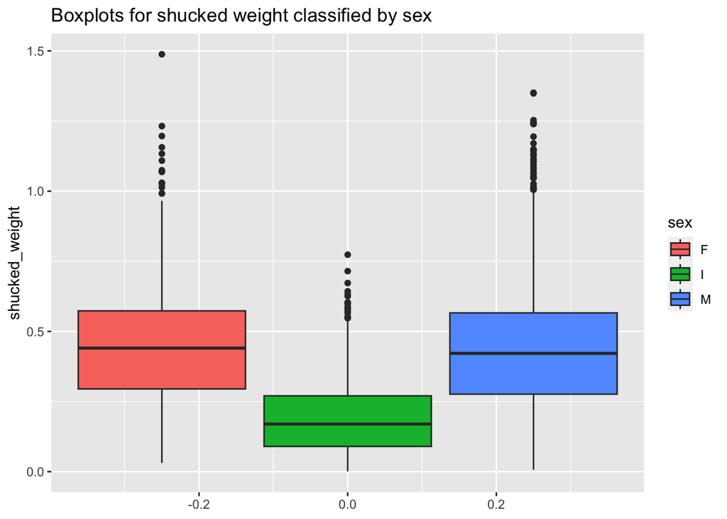

```r
#changing sex variable to a categorical type using factor
abalone_df$sex=factor(abalone_df$sex)

#plotting boxplots for different genders

ggplot(abalone_df, aes(y = shucked_weight, fill = sex)) +
  geom_boxplot() +
  labs(title = "Boxplots for shucked weight classified by sex")
```

#### B

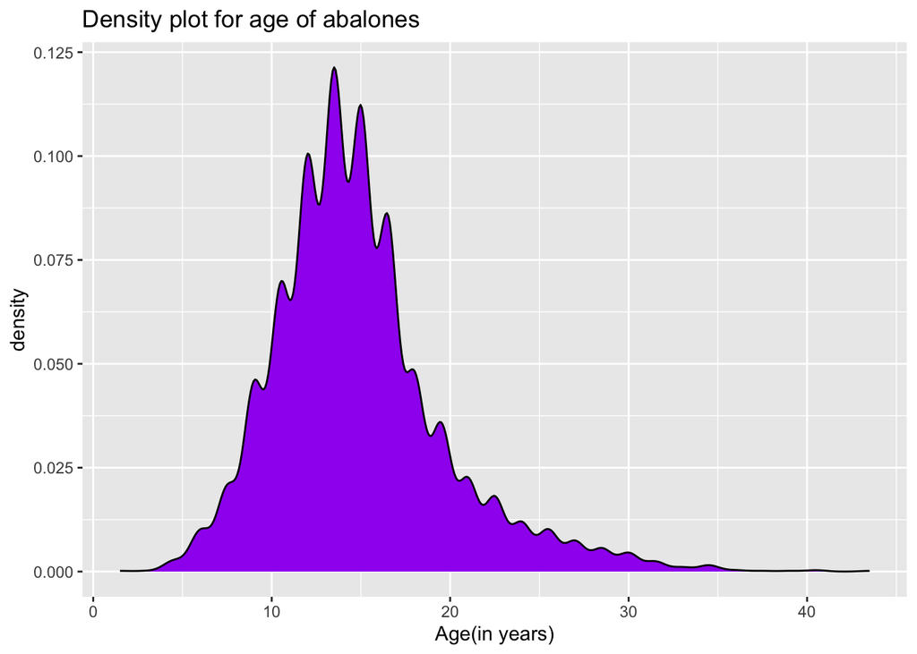

```r
#Adding a variable age
abalone_df$age=1.5*abalone_df$rings

#plotting probability distribution plot for abalone's age
ggplot(abalone_df, aes(x = age)) +
  geom_density(fill = 'purple') +
  labs(
    title = "Density plot for age of abalones",
    x = "Age(in years)"
  )
```

The distribution is right skewed and not symmetric, as evident from the distribution plot.

#### C

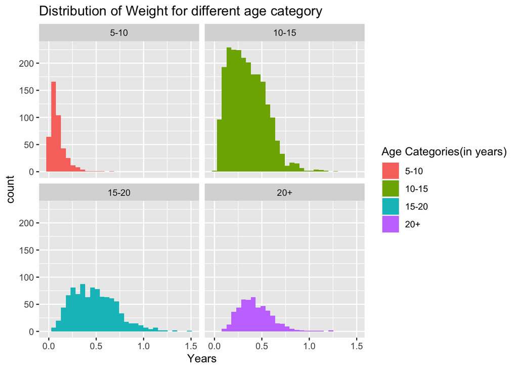

```r
# Defining age intervals for categories
category_intervals_age=c(5,10,15,20,Inf)

# Defining labels for intervals

#Added an extra age label of '0-5' as distribution plot for this interval's category was plotted as NA
abalone_df_filtered=abalone_df[abalone_df$age>5,]
category_labels_age=c('5-10','10-15','15-20','20+')


#Adding a column based on specified categories for age in dataframe
abalone_df_filtered$age_category=cut(abalone_df_filtered$age,
                                     breaks = category_intervals_age,
                                     labels = category_labels_age,
                                     right = TRUE)

#Plotting distribution of shucked weight per age category
ggplot(abalone_df_filtered, aes(x = shucked_weight, fill = age_category)) +
  geom_histogram() +
  labs(
    title = "Distribution of Weight for different age category",
    x = "Years",
    fill="Age Categories(in years)"
  ) +
  facet_wrap(~age_category)
```

#### D

```r
#select numeric variables of abalone_df
abalone_df_numeric <- abalone_df |>
  select_if(is.numeric)

#computing correlation matrix
correlation_mat=cor(abalone_df_numeric)
correlation_mat
```

```
                  length  diameter    height whole_weight shucked_weight
length         1.0000000 0.9868116 0.8275536    0.9252612      0.8979137
diameter       0.9868116 1.0000000 0.8336837    0.9254521      0.8931625
height         0.8275536 0.8336837 1.0000000    0.8192208      0.7749723
whole_weight   0.9252612 0.9254521 0.8192208    1.0000000      0.9694055
shucked_weight 0.8979137 0.8931625 0.7749723    0.9694055      1.0000000
viscera_weight 0.9030177 0.8997244 0.7983193    0.9663751      0.9319613
shell_weight   0.8977056 0.9053298 0.8173380    0.9553554      0.8826171
rings          0.5567196 0.5746599 0.5574673    0.5403897      0.4208837
age            0.5567196 0.5746599 0.5574673    0.5403897      0.4208837
               viscera_weight shell_weight     rings       age
length              0.9030177    0.8977056 0.5567196 0.5567196
diameter            0.8997244    0.9053298 0.5746599 0.5746599
height              0.7983193    0.8173380 0.5574673 0.5574673
whole_weight        0.9663751    0.9553554 0.5403897 0.5403897
shucked_weight      0.9319613    0.8826171 0.4208837 0.4208837
viscera_weight      1.0000000    0.9076563 0.5038192 0.5038192
shell_weight        0.9076563    1.0000000 0.6275740 0.6275740
rings               0.5038192    0.6275740 1.0000000 1.0000000
age                 0.5038192    0.6275740 1.0000000 1.0000000
```

```r
#finding index of shucked_weight in correlation matrix
index=which(colnames(correlation_mat)=="shucked_weight")

#finding index with max correlation
#excluding shucked_weight's correlation with self
max_index=which.max(correlation_mat[index,-index])

cat(paste0('Shucked weight has max correlation with ',
           colnames(correlation_mat)[max_index],
           ' and the correlation coefficient for the same = ',
           correlation_mat[index,max_index],'\n'))
```

```
Shucked weight has max correlation with whole_weight and the correlation coefficient for the same = 0.969405456703433
```

#### E

```r
plot1 = ggplot(abalone_df, aes(x = length, y= shucked_weight)) +
        geom_point() +
        labs(title = 'Shucked Weight Vs Length', y = 'Shucked Weight (grams)',
             x='Length')

plot2 = ggplot(abalone_df, aes(x = diameter, y= shucked_weight)) +
        geom_point() +
        labs(title = 'Shucked Weight Vs Diameter', y = 'Shucked Weight (grams)',
             x='Diameter')

plot3 = ggplot(abalone_df, aes(x = height, y= shucked_weight)) +
        geom_point() +
        labs(title = 'Shucked Weight Vs Height', y = 'Shucked Weight (grams)',
             x='Height')
```

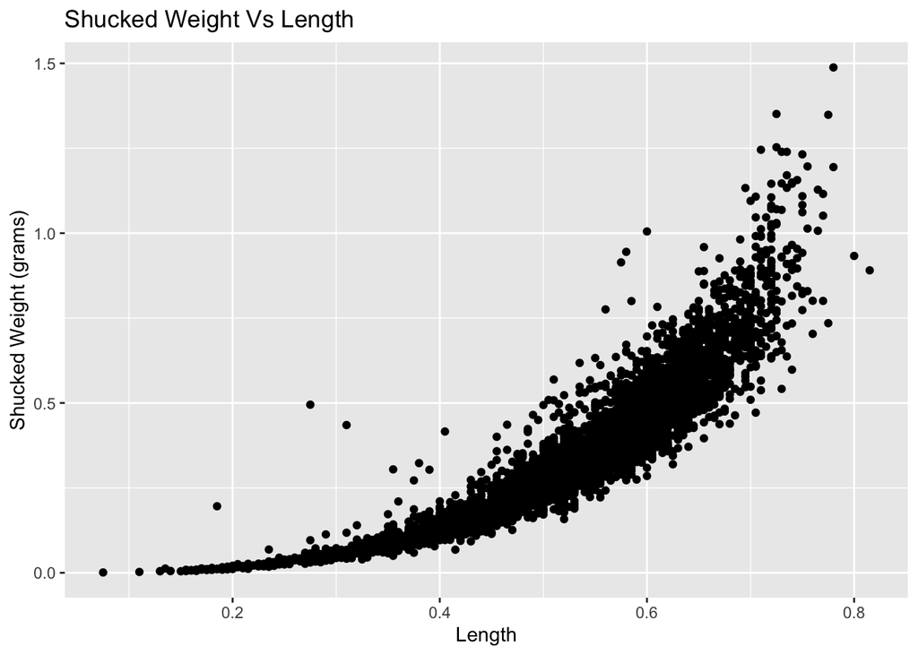

```r
print(plot1)
```

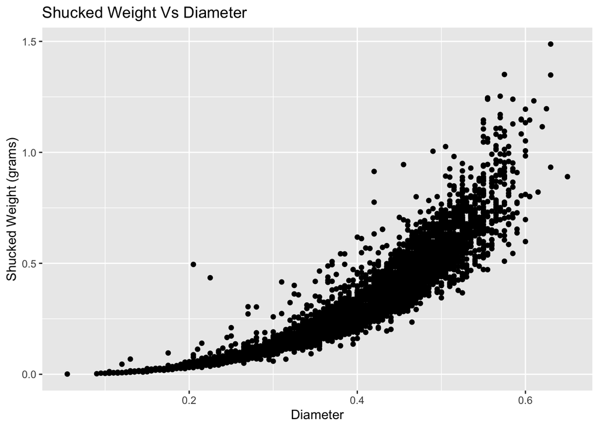

```r
print(plot2)
```

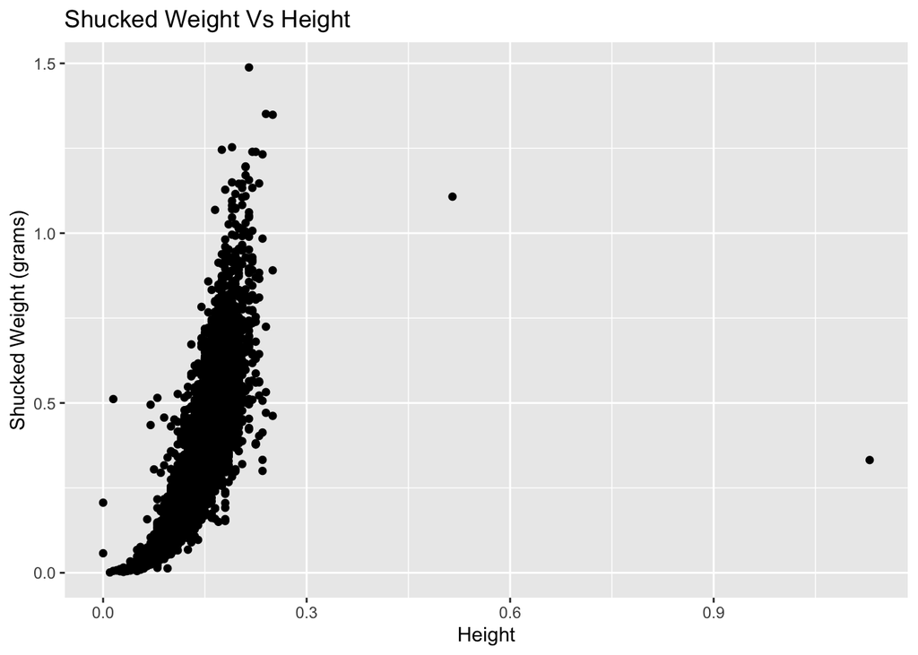

```r
print(plot3)
```

#### F

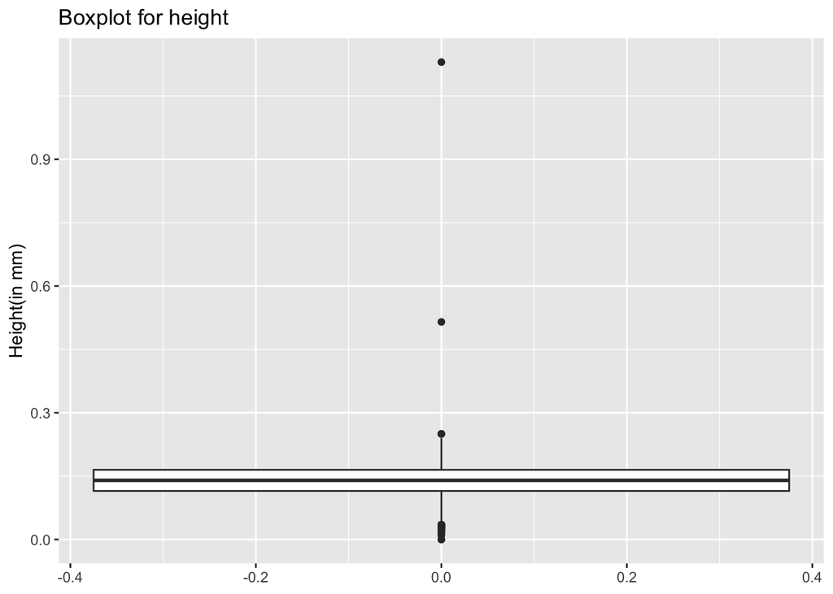

```r
# Boxplot for height to detect outliers
ggplot(abalone_df, aes(y = height)) +
  geom_boxplot() +
  labs(title = 'Boxplot for height',y='Height(in mm)')
```

#### G

```r
# fitting a linear regression model between shucked_weight and height
model1=lm(shucked_weight~height,data=abalone_df)
```

```r
# Model Summary
summary(model1)
```

```
Call:
lm(formula = shucked_weight ~ height, data = abalone_df)

Residuals:
    Min      1Q  Median      3Q     Max
-4.1008 -0.0764 -0.0180  0.0577  0.8182

Coefficients:
            Estimate Std. Error t value Pr(>|t|)
(Intercept) -0.21440    0.00756  -28.36   <2e-16 ***
height       4.11253    0.05190   79.23   <2e-16 ***
---
Signif. codes:  0 '***' 0.001 '**' 0.01 '*' 0.05 '.' 0.1 ' ' 1

Residual standard error: 0.1403 on 4175 degrees of freedom
Multiple R-squared:  0.6006,    Adjusted R-squared:  0.6005
F-statistic:  6278 on 1 and 4175 DF,  p-value: < 2.2e-16
```

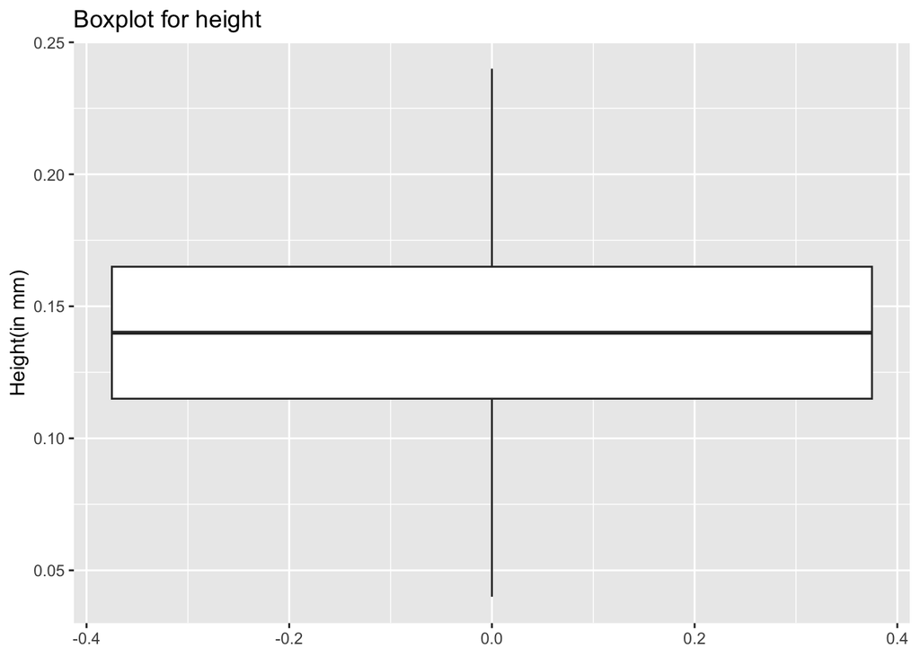

```r
#removing outliers in height using IQR method
#calculating quartiles
q1 <- quantile(abalone_df$height, 0.25)
q3 <- quantile(abalone_df$height, 0.75)
iqr <- q3 - q1

#calculating upper and lower limits
lower_limit = q1 - 1.5 * iqr
upper_limit = q3 + 1.5 * iqr

#filtering dataset
abalone_df_filtered= filter(abalone_df,(height >= lower_limit) &
                              (height <= upper_limit))

#boxplot of height with filtered values for verification
ggplot(abalone_df_filtered, aes(y = height)) +
  geom_boxplot() +
  labs(title = 'Boxplot for height',y='Height(in mm)')
```

As we can see from the boxplot of height with filtered values that the outliers have been removed.

```r
# fitting a linear regression model between shucked_weight and height
# after filtering out outliers
model2=lm(shucked_weight~height,data=abalone_df_filtered)
```

```r
# Model Summary
summary(model2)
```

```
Call:
lm(formula = shucked_weight ~ height, data = abalone_df_filtered)

Residuals:
     Min       1Q   Median       3Q      Max
-0.53021 -0.06705 -0.00638  0.05881  0.75640

Coefficients:
             Estimate Std. Error t value Pr(>|t|)
(Intercept) -0.328526   0.007178  -45.77   <2e-16 ***
height       4.930801   0.049601   99.41   <2e-16 ***
---
Signif. codes:  0 '***' 0.001 '**' 0.01 '*' 0.05 '.' 0.1 ' ' 1

Residual standard error: 0.1198 on 4146 degrees of freedom
Multiple R-squared:  0.7044,    Adjusted R-squared:  0.7044
F-statistic:  9882 on 1 and 4146 DF,  p-value: < 2.2e-16
```

As we can see, the slope of the regression line has increased a bit after removing outliers in height and also the coefficient of determination has improved for the second model which means that outliers can have an effect on estimating regression slope as outliers tend to pull the regression line towards itself,therefore increasing the error in estimation and wider confidence intervals.

#### H

```r
model=lm(shucked_weight ~ length + diameter + height + rings, data = abalone_df)
summary(model)
```

```
Call:
lm(formula = shucked_weight ~ length + diameter + height + rings,
    data = abalone_df)

Residuals:
     Min       1Q   Median       3Q      Max
-0.60995 -0.06106 -0.01701  0.04044  0.66542

Coefficients:
              Estimate Std. Error t value Pr(>|t|)
(Intercept) -0.4673450  0.0068785 -67.943  < 2e-16 ***
length       1.0166016  0.0745563  13.635  < 2e-16 ***
diameter     0.7308167  0.0924717   7.903 3.45e-15 ***
height       0.6786035  0.0635168  10.684  < 2e-16 ***
rings       -0.0099401  0.0005569 -17.849  < 2e-16 ***
---
Signif. codes:  0 '***' 0.001 '**' 0.01 '*' 0.05 '.' 0.1 ' ' 1

Residual standard error: 0.09315 on 4172 degrees of freedom
Multiple R-squared:  0.8241,    Adjusted R-squared:  0.8239
F-statistic:  4885 on 4 and 4172 DF,  p-value: < 2.2e-16
```

Equation of Regression: $\hat{Y} = -0.4673450 + 1.0166016\cdot length + 0.7308167\cdot diameter + 0.6786035\cdot height - 0.0099401\cdot rings$ From the model summary, $R^2 = 0.8241$ which is better than the previous values of $R^2$, this means that our model can explain 82% variation in the output variable y: shucked_weight.Since the model with the current combination of predictors is better, we conclude that the set of predictors selected is statistically significant to explain the variation in shucked weight.

#### I

```r
#Creating data table containing inputs for prediction
inputs = data.table(length = 0.456, diameter = 0.351, height = 0.102, rings = 13.5)

# Getting prediction interval for the given input
shucked_weight_predicted = predict(model, newdata = inputs, interval = "prediction",
                                   level = 0.95)

# Getting the upper and lower bound
lower_limit =  shucked_weight_predicted[2]
upper_limit = shucked_weight_predicted[3]

cat("95% Prediction Interval for Shucked Weight:\n")
```

```
95% Prediction Interval for Shucked Weight:
```

```r
cat(paste0("(",lower_limit," , ",upper_limit,")"))
```

```
(0.00502326121045835 , 0.37051404136645)
```